# Data Exploration in R

Barbara Casillas

1/27/2022

## Messy data into time-analytical insight

This R Markdown document chronicles a mission to take quite messy sports data provided by Viviene Roussez to implement and understand time series analysis.

```r
library(dplyr)
library(ggplot2)
library(lubridate)
library(plotly)
library(GGally)
library(ggpubr)
library(zoo)
library(forecast)
library(seasonal)
```

We have a dataset with sport activities, already nicely arranged into a dataset, with one row per event, along with time of event and a handful of metrics recorded by a Garmin device over ten years. I will focus on outdoor cycling events and a few relevant metrics.

```r
data<-readRDS(file = "./data/dat_clean.rds")%>% #data_clean from ZZ2-data_preparation.R
              filter(activityType%in%c("cycling"))%>%droplevels()%>%
              select(activityType,#what
                     start_time, #when
                     duration, distance, avgSpeed, maxSpeed,#how long, far,fast
                     elevationGain, #elevation change (gain~loss)
                     avgHr,#heart rate
                     avgPower,max20MinPower,#power
                     avgBikeCadence,#cadence
                     calories) #energy
```

Inspecting the summary statistics of the data set already indicates there is some anomalous data, possibly measurment errors, that I will exclude.

```r
data<-filter(data,duration>10,avgSpeed>5,!(maxSpeed>120),elevationGain<3000)
```

In time series analysis there shouldn’t be duplicated events. I found one, “2016-11-01 14:52:50”

```r
data<-data[-1371,]
```

A correlogram of all variables already gives quite an insight. As expected, cadence is moderately negatively correlated with elevation gain. There are considerable positive correlations between distance, duration and calories, and between power and speed variables.

[figure not shown]

```r
library(corrgram)
corrgram(select(data,-c(activityType)),
         order=T, lower.panel=panel.shade,
        diag.panel=panel.density,
         upper.panel=NULL)
```

Besides the correlations, the distributions are bimodal, possibly reflecting two types of cycling, e.g. with a slower mountain bike and with faster road bike.

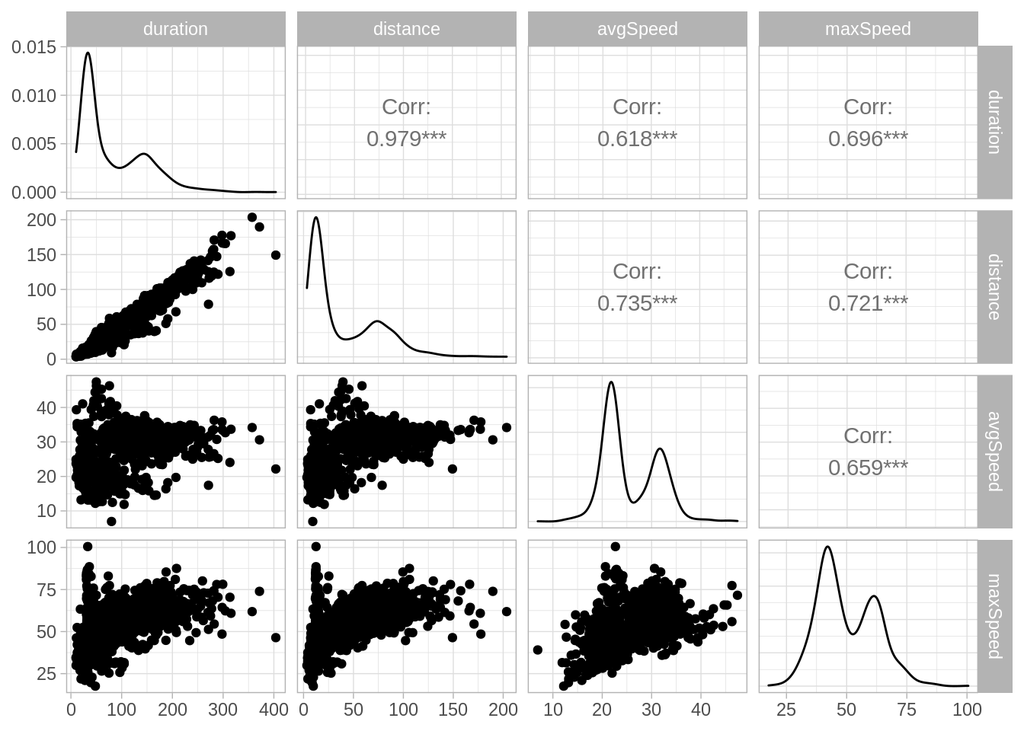

```r
ggpairs(select(data,duration,distance,avgSpeed, maxSpeed))+theme_light()
```

So to start a time series analysis, considering that these variables are time series, i.e. metrics of Vivienne’s cylcing performance were gathered over time, we can do some visual exploration first, plotting the variables with respect to time. We can parse the time variable ‘start_time’ with ‘lubridate’.

```r
data<-data%>% mutate(year=year(data$start_time),
                    month=month(data$start_time),
                    weekday=wday(data$start_time,week_start = 1),
                    hour=hour(data$start_time))
```

Most cycling events start at 7-8am or 5-6pm, they are perhaps commute to and from work.

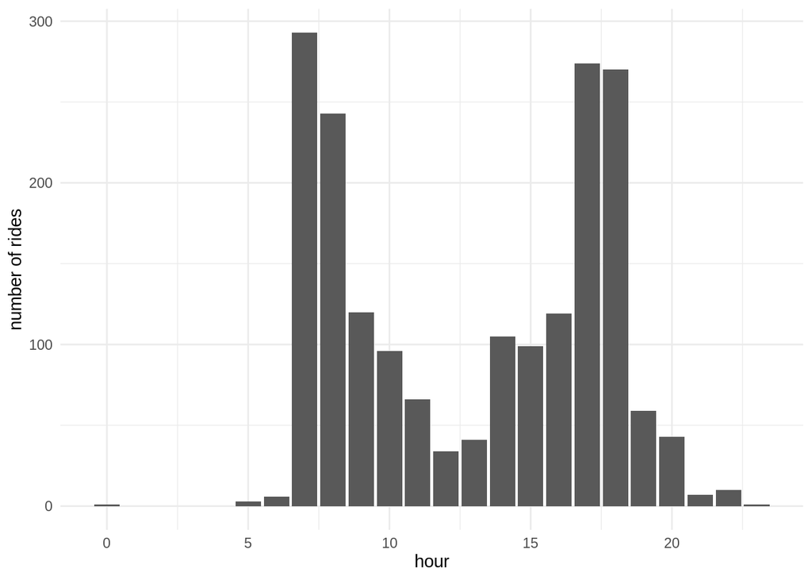

```r
ggplot(data,aes(x=hour))+geom_bar()+theme_minimal()+ylab("number of rides")
```

And the least number of rides happen during the weekend Fri-Sun (left), although long rides (above 2 hours), happen mostly during the weekend (right).

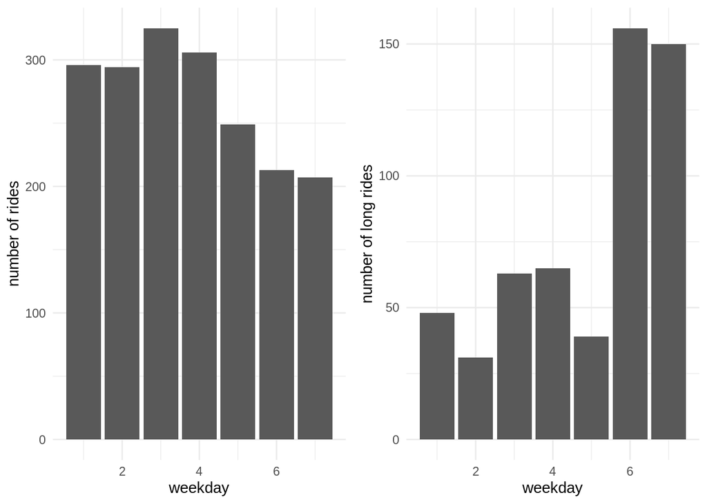

```r
a<-ggplot(data,aes(x=weekday))+geom_bar()+theme_minimal()+ylab("number of rides")
b<-ggplot(filter(data,duration>120),aes(x=weekday))+geom_bar()+theme_minimal()+ylab("number of long rides")
ggarrange(a,b,ncol = 2,widths = c(1,1))
```

With respect to monthly patterns, it is clear that less and shorter rides happen during the winter months

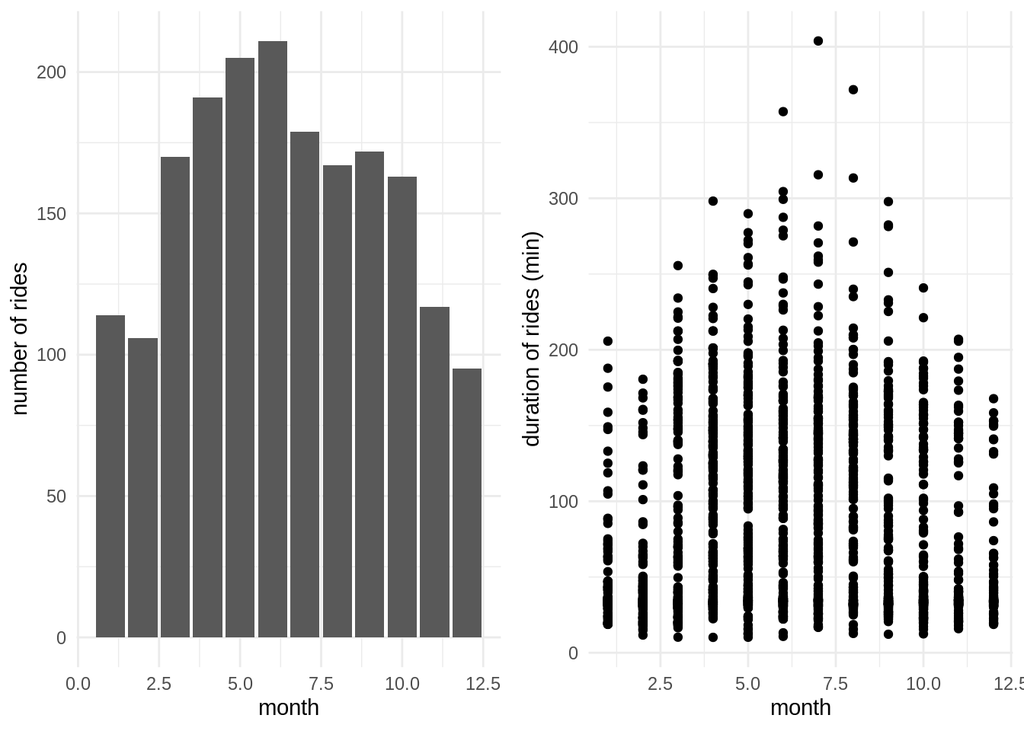

```r
c<-ggplot(data,aes(x=month))+geom_bar()+theme_minimal()+ylab("number of rides")
d<-ggplot(data,aes(duration,x=month))+geom_point()+theme_minimal()+ylab("duration of rides (min)")
ggarrange(c,d,ncol = 2,widths = c(1,1))
```

### Time series analysis

Knowing already that there are hourly, weekly, and monthly patterns, we remove some complexity from the data. We can aggregate the data, to have a single value per month. Months with no data, can be imputed with an interpolation.

```r
mdata <- data %>% mutate(time =  as.Date(cut(start_time, "month")))%>%
  group_by(time) %>%
  summarise(mduration = sum(duration,na.rm=T), #total duration of all rides in a month
            endurance = max(duration,na.rm=T), #new! maximum duration of a ride in a month
         distance = sum(distance,na.rm=T), #total distance in a month
         avgSpeed = mean(avgSpeed,na.rm=T),#average over ride and again over month
         maxSpeed = max(maxSpeed,na.rm=T), #max over month
         avgPower =mean(avgSpeed,na.rm=T)) #average over ride and again over month

mdata<-mdata %>% # NA rows in missing months
  tidyr::complete(time = seq.Date(min(time), max(time), by = "month"))
library(imputeTS)
mdata<-na_interpolation(mdata)  #impute NA rows with interpolation
```

Some variables like, endurance (max duration in a month) show marked seasonality.

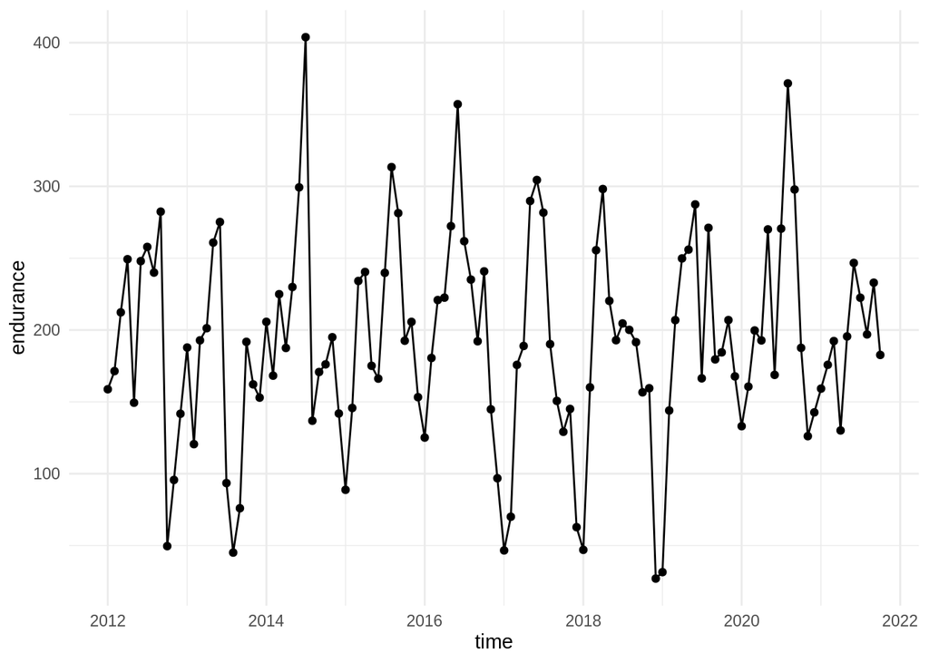

```r
ggplot(mdata,aes(endurance,x=time))+geom_line()+geom_point()+theme_minimal()
```

We can create a time series object in many ways. The ‘zoo’ and ‘ts’ libraries are the most popular.

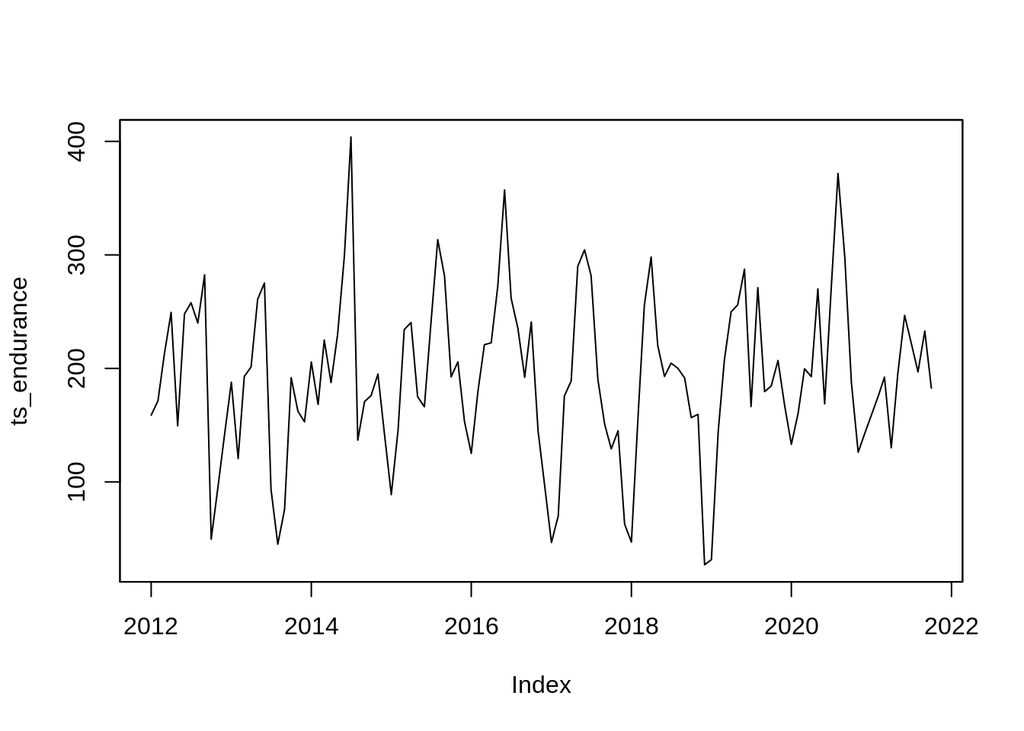

```r
ts_endurance <- zoo(mdata$endurance, mdata$time)
plot(ts_endurance)
```

We can decompose a time series into its components: trend, seasonal and random component.

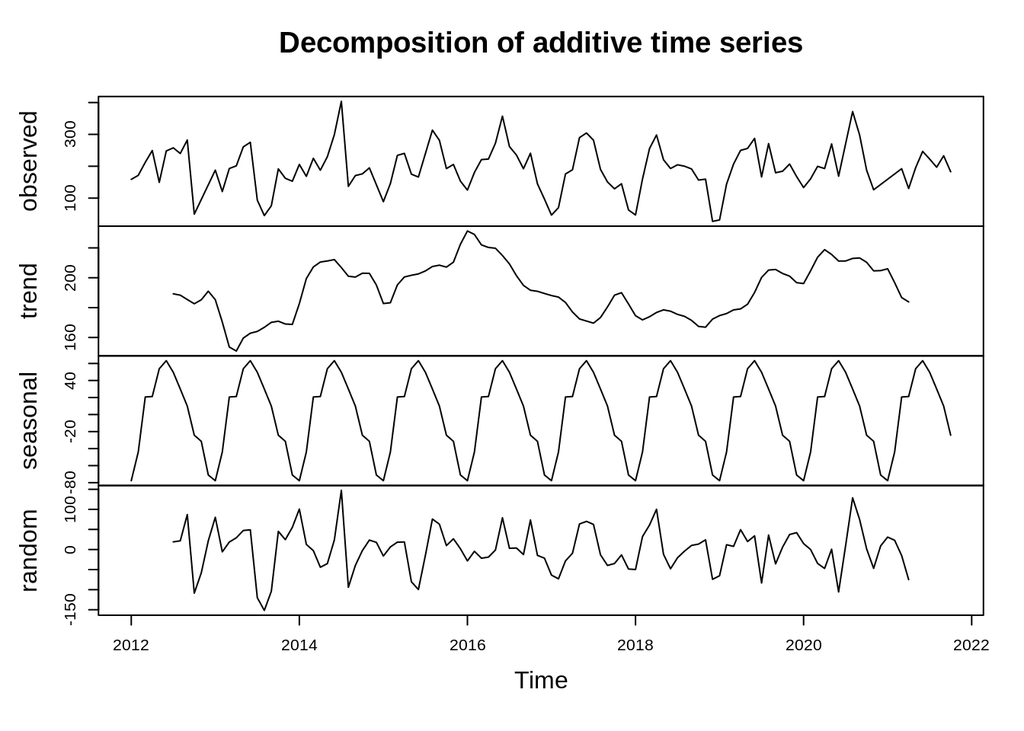

```r
ts_endurance = ts(mdata$endurance, start = c(2012,1), frequency = 12)
components.ts = decompose(ts_endurance) #to see clear seasonal component #endurance, is max duration
plot(components.ts)
```

We can de-trend a timeseries.

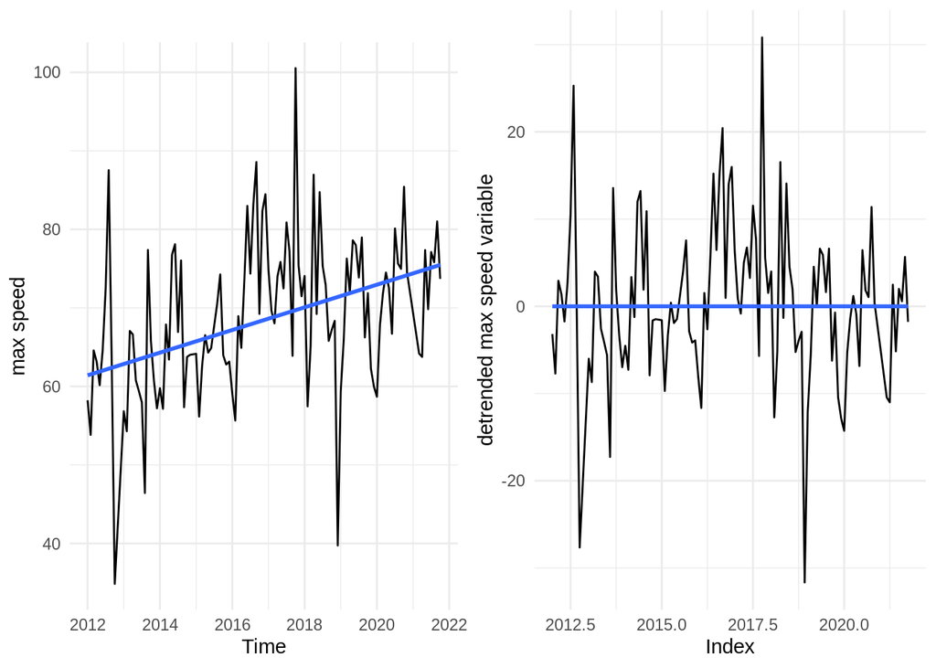

```r
ts_maxSpeed = ts(mdata$maxSpeed, start = c(2012,1), frequency = 12)
m <- lm(coredata(ts_maxSpeed) ~ index(ts_maxSpeed))
e=autoplot(ts_maxSpeed)+theme_minimal()+geom_smooth(method="lm",se=F)+ylab("max speed")
detr <- zoo(resid(m), index(ts_maxSpeed))
f=autoplot(detr)+theme_minimal()+geom_smooth(method="lm",se=F)+ylab("detrended max speed variable")
ggarrange(e,f,ncol = 2,widths = c(1,1))
```

There are other packages (e.g. ‘seasonal’) to decompose time series,(with different tecniques)

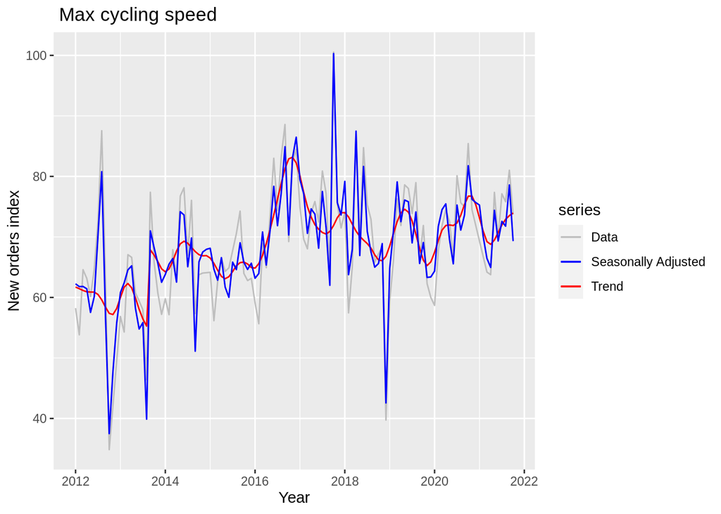

```r
ts_maxSpeed %>% seas(x11="") -> fit
autoplot(ts_maxSpeed, series="Data") +
  autolayer(trendcycle(fit), series="Trend") +
  autolayer(seasadj(fit), series="Seasonally Adjusted") +
  xlab("Year") + ylab("New orders index") +
  ggtitle(" Max cycling speed") +
  scale_colour_manual(values=c("gray","blue","red"),
                      breaks=c("Data","Seasonally Adjusted","Trend"))
```

The most popular R package to perform time series analysis to date is ‘forecast’. With it we can easily visualize seasonal trends.

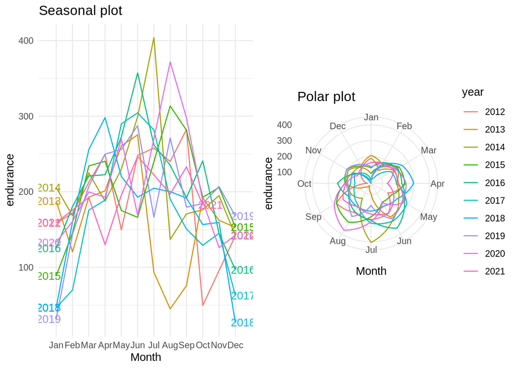

```r
g<-ggseasonplot(ts_endurance, year.labels=TRUE, year.labels.left=TRUE) +
  ylab("endurance") + ggtitle("Seasonal plot")+theme_minimal()
h<-ggseasonplot(ts_endurance,polar=TRUE) +
  ylab("endurance") +  ggtitle("Polar plot")+theme_minimal()
ggarrange(g,h,ncol = 2,widths = c(1,1))
```

With the ‘forecast’ package, obviously, we can also make forecasts.

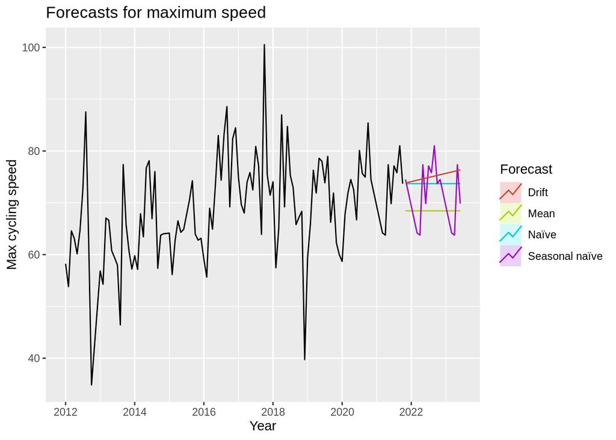

```r
autoplot(ts_maxSpeed) +
  autolayer(meanf(ts_maxSpeed, h=20),
            series="Mean", PI=FALSE) +
  autolayer(naive(ts_maxSpeed, h=20),
            series="Naïve", PI=FALSE) +
  autolayer(snaive(ts_maxSpeed, h=20),
            series="Seasonal naïve", PI=FALSE) +
  autolayer(rwf(ts_maxSpeed, drift=TRUE, h=20),
            series="Drift", PI=FALSE) +
  ggtitle("Forecasts for maximum speed") +
  xlab("Year") + ylab("Max cycling speed") +
  guides(colour=guide_legend(title="Forecast"))
```

Forecast function ‘snaive’ returns forecasts and prediction intervals from an ARIMA(0,0,0)(0,1,0)m model where m is the seasonal period (in this case 12).

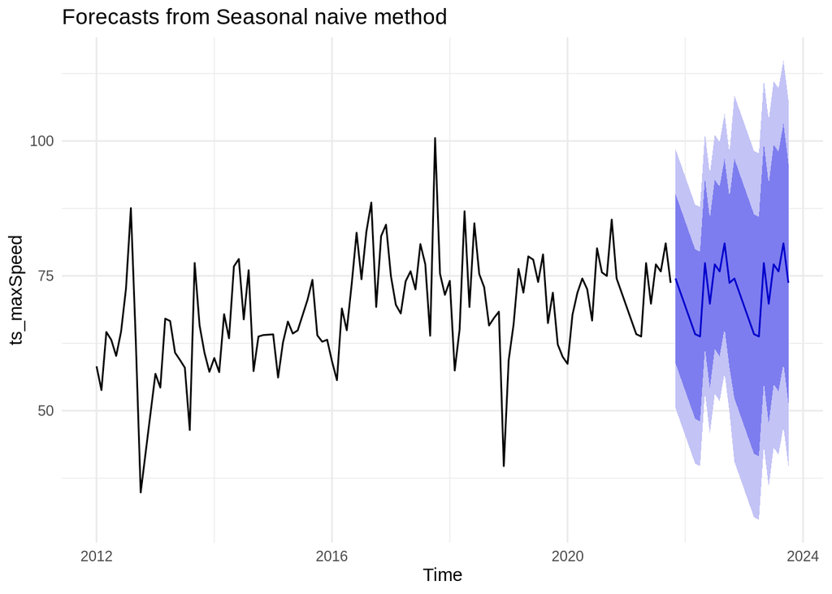

```r
fc<-snaive(ts_maxSpeed)
autoplot(fc)+theme_minimal()
```

One can readily inspect the model and residuals, to try to understand if this is a good forecast.

```r
summary(fc)
```

```
##
## Forecast method: Seasonal naive method
##
## Model Information:
## Call: snaive(y = ts_maxSpeed)
##
## Residual sd: 12.2464
##
## Error measures:
##                    ME     RMSE      MAE      MPE     MAPE MASE     ACF1
## Training set 1.425594 12.24641 9.068632 0.673743 13.38627    1 0.163668
##
## Forecasts:
##          Point Forecast    Lo 80     Hi 80    Lo 95     Hi 95
## Nov 2021        74.5020 58.80759  90.19641 50.49947  98.50453
## Dec 2021        71.9244 56.22999  87.61881 47.92187  95.92693
## Jan 2022        69.3468 53.65239  85.04121 45.34427  93.34933
## Feb 2022        66.7692 51.07479  82.46361 42.76667  90.77172
## Mar 2022        64.1916 48.49719  79.88601 40.18907  88.19412
## Apr 2022        63.7560 48.06159  79.45041 39.75347  87.75852
## May 2022        77.3604 61.66599  93.05481 53.35787 101.36293
## Jun 2022        69.8364 54.14199  85.53081 45.83387  93.83893
## Jul 2022        77.1228 61.42839  92.81721 53.12027 101.12533
## Aug 2022        75.8124 60.11799  91.50681 51.80987  99.81493
## Sep 2022        81.0216 65.32719  96.71601 57.01908 105.02413
## Oct 2022        73.6992 58.00479  89.39361 49.69667  97.70173
## Nov 2022        74.5020 52.30675  96.69724 40.55730 108.44670
## Dec 2022        71.9244 49.72915  94.11964 37.97970 105.86910
## Jan 2023        69.3468 47.15155  91.54204 35.40210 103.29150
## Feb 2023        66.7692 44.57395  88.96444 32.82450 100.71390
## Mar 2023        64.1916 41.99635  86.38684 30.24690  98.13630
## Apr 2023        63.7560 41.56075  85.95124 29.81130  97.70070
## May 2023        77.3604 55.16516  99.55565 43.41570 111.30510
## Jun 2023        69.8364 47.64115  92.03165 35.89170 103.78110
## Jul 2023        77.1228 54.92756  99.31805 43.17810 111.06750
## Aug 2023        75.8124 53.61715  98.00765 41.86770 109.75710
## Sep 2023        81.0216 58.82636 103.21685 47.07690 114.96630
## Oct 2023        73.6992 51.50395  95.89445 39.75450 107.64390
```

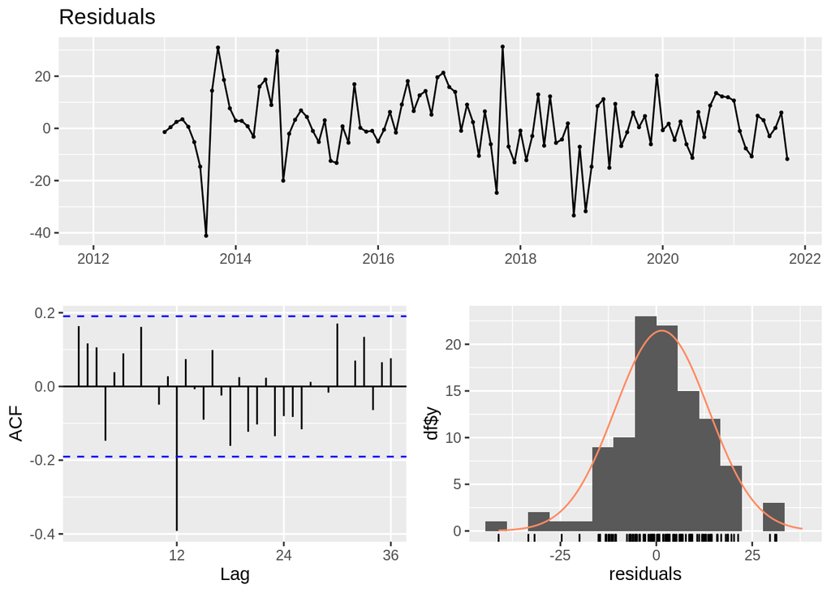

```r
res <- residuals(fc)
checkresiduals(res)
```

The large value of the ACF at 12, indicates a large auto-correlation of the values with lag=12, i.e. yearly seasonality.